[Getting Started Guide](http://iqtk.io) // [Documentation Feedback](https://goo.gl/forms/2cOmuUrQ3n3CKpim1)

# Gene expression analysis

In this analysis we perform differential expression analysis with the Cufflinks toolset which includes [cufflinks](https://cole-trapnell-lab.github.io/cufflinks/), [tophat](https://ccb.jhu.edu/software/tophat/), and [bowtie2](http://bowtie-bio.sourceforge.net/bowtie2/index.shtml). You can brush up on gene expression profiling [here](https://en.wikipedia.org/wiki/Gene_expression_profiling).

There is some background reading so once you've completed the getting started documentation you'll be ready for this tutorial!

## Required Data and Parameterization

The starting point for this workflow is the following:

**1. Reference FASTA:** GCS path to reference genome assembly in FASTA format (aginst which to align reads).

**3. Condition A pairs:** A comma-separated list of read pairs belonging to condition A.

**2. Condition B pairs:** A comma-separated list of read pairs belonging to condition B.

Each of these should be present on Google Cloud Storage. A cloud storage containing FASTQ base calls for a transcriptome sequencing run on the MiSeq sequencer is shown below.

[figure not shown]

1. Using the `iqtk` command-line tool

2. Programmatically in response to an instrument data sync event.

Initiating workflow runs from the command line requires that the `iqtk` utility is installed on your system (such as via `pip install iqtk`) and that you have authenticated with GCP to access the APIs and file objects referenced by and required for your run. Provided these, a workflow can be initiated using the following command provided a JSON config file like the one following that.

```python
%%bash
iqtk run transcriptomics --config=path_to_your_config.json
```

```
{
  "dry_run": false,
  "cloud": true,
  "local": false,
  "ref_fasta": "gs://iqtk/dmel/bt2/genome.fa",
  "genes_gtf": "gs://iqtk/dmel/annotation/genes.gtf",
  "cond_a_pairs": [
      ["gs://iqtk/rnaseq/GSM794483_C1_R1_1_small.fq",
       "gs://iqtk/rnaseq/GSM794483_C1_R1_2_small.fq"]
      ],
  "cond_b_pairs": [
       ["gs://iqtk/rnaseq/GSM794486_C2_R1_1_small.fq",
        "gs://iqtk/rnaseq/GSM794486_C2_R1_2_small.fq"]
       ]
}
```

Once our job is submitted we'll be able to check its status using the Cloud DataFow UI as described in the getting started documentation. For illustration this workflow should look like the following:

[figure not shown]

For the interested you can check out the full code for this workflow [here](https://github.com/iqtk/iqtk/blob/master/inquiry/toolkit/rna_quantification/workflow.py).

## Exploring the data

When the workflow is complete you can obtain the path in Google Cloud Storage to the resulting files as described in the getting started documentation. Workflow runs produce raw data as well as BigQuery database entries. We can explore the latter through the BigQuery UI, provided the project, dataset, and table destination provided in our input. This should look like the following:

[figure not shown]

Next we'll pull down a subset of this data from BigQuery into a Pandas data_frame permitting further exploratory and interactive usage.

```python
import google.datalab.bigquery as bq
query = bq.Query('SELECT * FROM `jbei-cloud.somedataset.sometable2` LIMIT 3')
output_options = bq.QueryOutput.table(use_cache=False)
result = query.execute(output_options=output_options).result()
result.to_dataframe()
```

|  | id | geneid | gene | locus | sample1 | sample2 | status | expression1 | expression2 | lnFoldChange | testStatistic | pValue | qValue | significant |
| --- | --- | --- | --- | --- | --- | --- | --- | --- | --- | --- | --- | --- | --- | --- |
| 0 | XLOC_001687 | XLOC_001687 | l(2)05714 | 2L:4969003-4971453 | C1 | C2 | NOTEST | None | None | None | None | 1.0 | 1.0 | None |
| 1 | XLOC_014024 | XLOC_014024 | CG14408 | X:14721090-14726090 | C1 | C2 | NOTEST | None | None | None | None | 1.0 | 1.0 | None |
| 2 | XLOC_000602 | XLOC_000602 | gcm2 | 2L:9608478-9612710 | C1 | C2 | NOTEST | None | None | None | None | 1.0 | 1.0 | None |

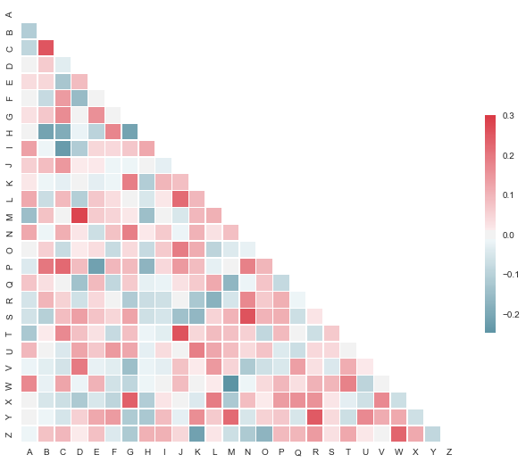

```python
# TODO: At this point, we can do anything that can be done with a pandas dataframe. For example:
from string import ascii_letters
import numpy as np
import pandas as pd
import seaborn as sns
import matplotlib.pyplot as plt
%matplotlib inline

sns.set(style="white")

# Generate a large random dataset
rs = np.random.RandomState(33)
d = pd.DataFrame(data=rs.normal(size=(100, 26)),
                 columns=list(ascii_letters[26:]))

# Compute the correlation matrix
corr = d.corr()

# Generate a mask for the upper triangle
mask = np.zeros_like(corr, dtype=np.bool)
mask[np.triu_indices_from(mask)] = True

# Set up the matplotlib figure
f, ax = plt.subplots(figsize=(11, 9))

# Generate a custom diverging colormap
cmap = sns.diverging_palette(220, 10, as_cmap=True)

# Draw the heatmap with the mask and correct aspect ratio
sns.heatmap(corr, mask=mask, cmap=cmap, vmax=.3, center=0,
            square=True, linewidths=.5, cbar_kws={"shrink": .5})
```

### References

1. Trapnell, Cole, et al. "Differential gene and transcript expression analysis of RNA-seq experiments with TopHat and Cufflinks." Nature protocols 7.3 (2012): 562-578.
2. Trapnell, Cole, Lior Pachter, and Steven L. Salzberg. "TopHat: discovering splice junctions with RNA-Seq." Bioinformatics 25.9 (2009): 1105-1111.
3. Langmead, Ben, and Steven L. Salzberg. "Fast gapped-read alignment with Bowtie 2." Nature methods 9.4 (2012): 357-359.

### Contact

Want to get in touch? You can [provide feedback](https://goo.gl/forms/2cOmuUrQ3n3CKpim1) regarding this or other documentation, [reach out to us](https://goo.gl/forms/j8FWdNJqABAoJvcW2) regarding collaboration, or [request a new feature or analytical capability](https://goo.gl/forms/dQm3SDcoNZsV7AAd2). We're looking forward to hearing from you!

This notebook was prepared as part of the [Inquiry Toolkit](https://github.com/iqtk/iqtk) project at the Joint BioEnergy Institute (JBEI). Learn more at https://www.jbei.org/.

The Joint BioEnergy Institute is a program of the U.S. Department of Energy Office of Science.

© Regents of the University of California, 2017. Licensed under a BSD-3 [license](https://github.com/iqtk/iqtk/blob/master/LICENSE).